# R Bootcamp: ggplot2 Introduction

Ryan Wesslen

June 15, 2017

## Load file & tidyverse

Let’s consider visualizations. Let’s call [`tidyverse`](http://tidyverse.org/) and read in our file. For more details, check out [this great blog post on `tidyverse`](https://www.r-bloggers.com/what-is-the-tidyverse/).

```r
#install.packages("tidyverse")
library(tidyverse)

d <- read_csv("./Data/data.csv")
```

## Intro to ggplot2

`ggplot2` is based on the grammar of graphics, a flexible graph framework that includes three major parts:

1. dataset
2. geoms (visual markers)
3. coordinate system

It’s a phenomenal framework that allows a wide range of polished, publication-ready graphs including:

- scatter plots
- bar plots
- histograms
- maps
- many other plots (e.g., heatmaps, box plots, contour plots)

There is a handy [`ggplot` cheatsheet](https://www.rstudio.com/wp-content/uploads/2015/03/ggplot2-cheatsheet.pdf) that is very helpful in summarizing the flexibility `ggplot` offers.

Alternatively, you can access this cheatsheet through RStudio simply through Help > Cheatsheets.

Also, **aethestic properties** are very important to know. Sometimes just called aethestics, these are parameters like size, color or location that provide information about properties about geoms. These are typically used within the main `ggplot` function with the properties wrapped within the function `aes()`.

### Histogram / Density

So let’s use our dataset to run a simple histogram plot to explore the range of Mortality rates by country.

Given our data is panel data, let’s simplify and only keep records in 2014.

```r
# here are two ways to keep only 2014
pop2014 <- filter(d, year == 2014)
pop2014 <- d[d$year==2014,]
```

We can use `ggplot2` simply with the function `ggplot()`.

This function includes two major inputs: data and mapping.

Also, the functions also includes the **geoms** that specify ways to represent the data.

For example, to represent a histogram, we’ll use [`geom_histogram()`](http://ggplot2.tidyverse.org/reference/geom_histogram.html).

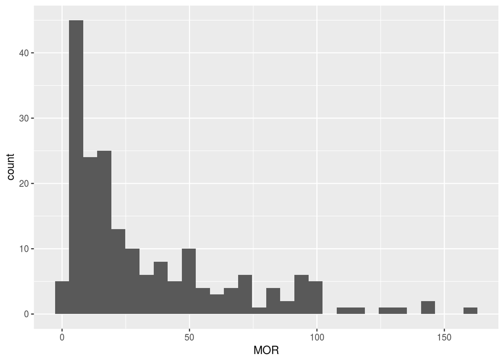

```r
#?ggplot

ggplot(pop2014, mapping = aes(MOR)) + # Pro tip: ggplot can have multiple layers.
  geom_histogram()                    # A best practice is to organize them by line to aid in reading
```

This gets us started but far from perfect. Alternatively, perhaps we can to use a plot/density instead.

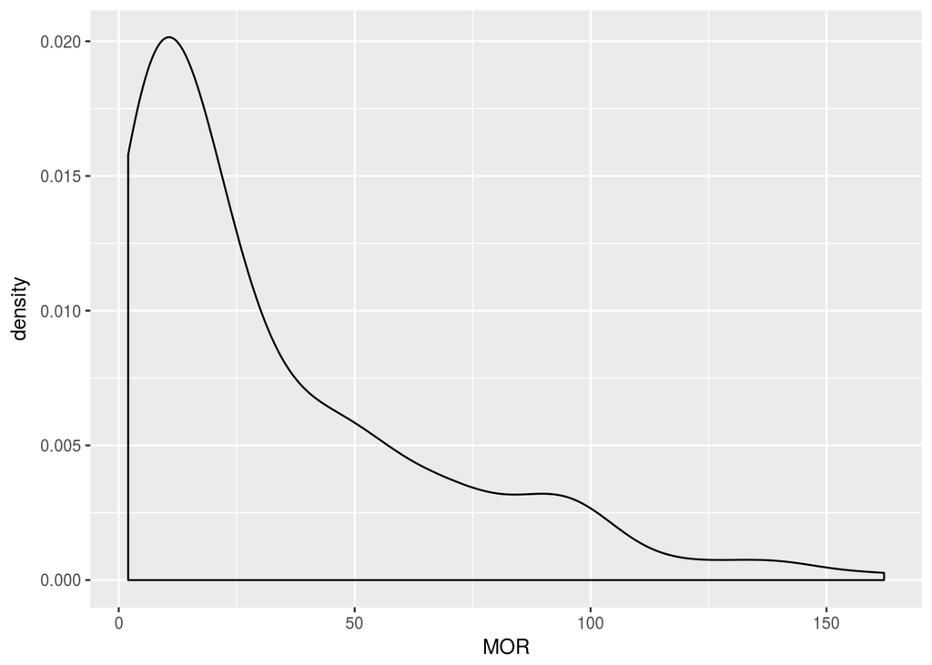

```r
ggplot(pop2014, mapping = aes(MOR)) +
  geom_density()
```

Ah, that’s much better. However, these plots are subject to the bandwidth (density).

We can create more granular plots by modifying the `adjust` parameter. For example, a value of `adjust` = 0.5 means we’ll use half the default bandwidth.

Let’s go with a very granular bandwidth by setting `adjust` = 0.2.

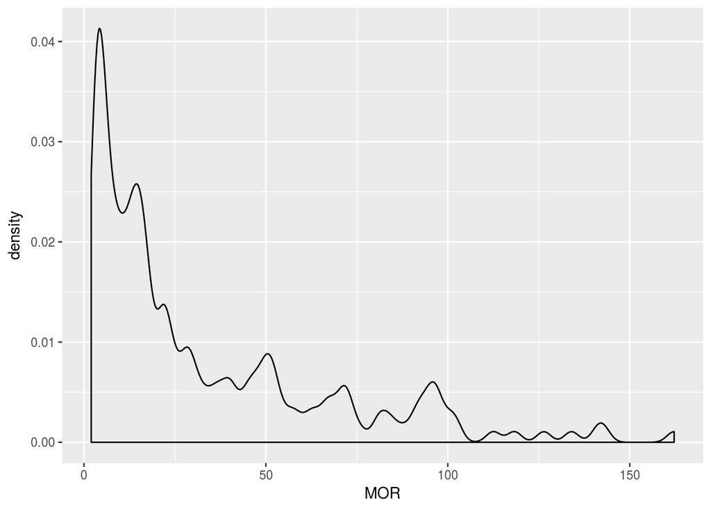

```r
ggplot(pop2014, mapping = aes(MOR)) +
  geom_density(adjust = 0.2)
```

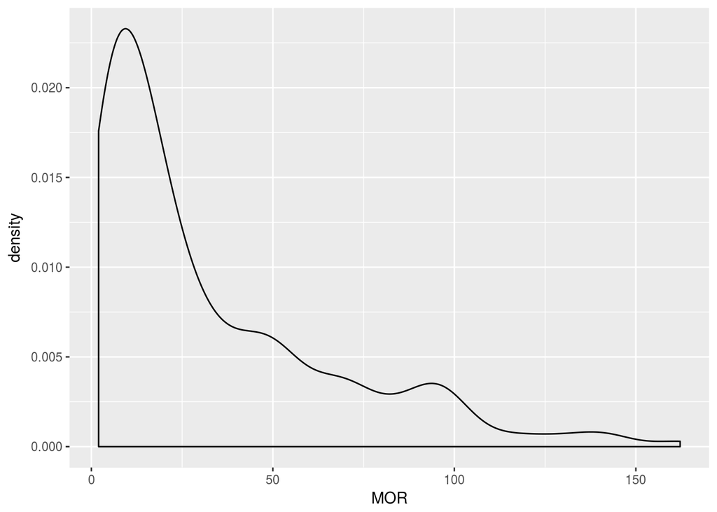

```r
ggplot(pop2014, mapping = aes(MOR)) +
  geom_density(adjust = 0.75)
```

This is much better. However, let’s consider how this distribution differs by region.

To analyze by region, we’ll use the `color` aes parameter.

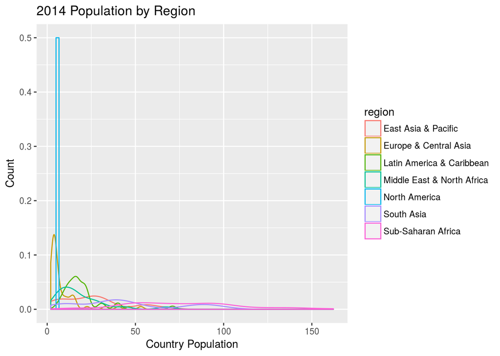

```r
ggplot(pop2014, mapping = aes(MOR, color = region)) +
  geom_density(adjust = 0.75) +
  labs(title = "2014 Population by Region", x = "Country Population", y = "Count")
```

One initial observation is that North America is finely distributed, leading to a very high spike.

Let’s remove North America using a subset function.

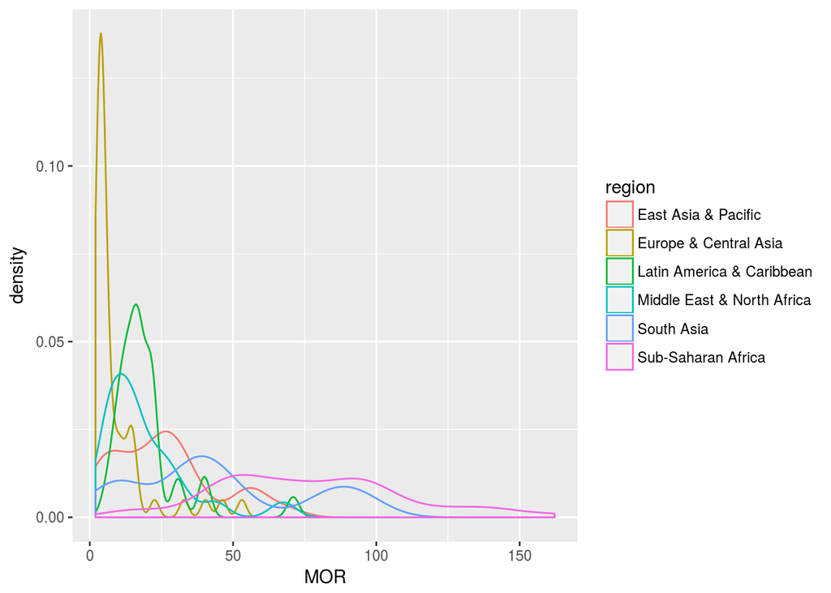

```r
ggplot(pop2014[pop2014$region != "North America",], mapping = aes(MOR, color = region)) +
  geom_density(adjust = 0.75)
```

Last, let’s clean up the labels and legend.

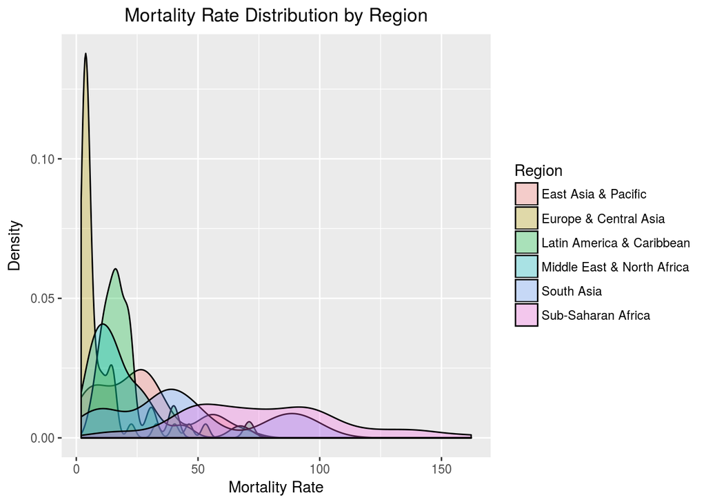

```r
ggplot(pop2014[pop2014$region != "North America",], mapping = aes(MOR, fill = region)) +
  geom_density(adjust = 0.75, alpha = 0.3) +
  labs(x = "Mortality Rate", y = "Density") +
  ggtitle("Mortality Rate Distribution by Region") +
  theme(plot.title = element_text(hjust = 0.5)) +
  scale_fill_discrete(guide = guide_legend(title = "Region")) # Changes the Legend Title
```

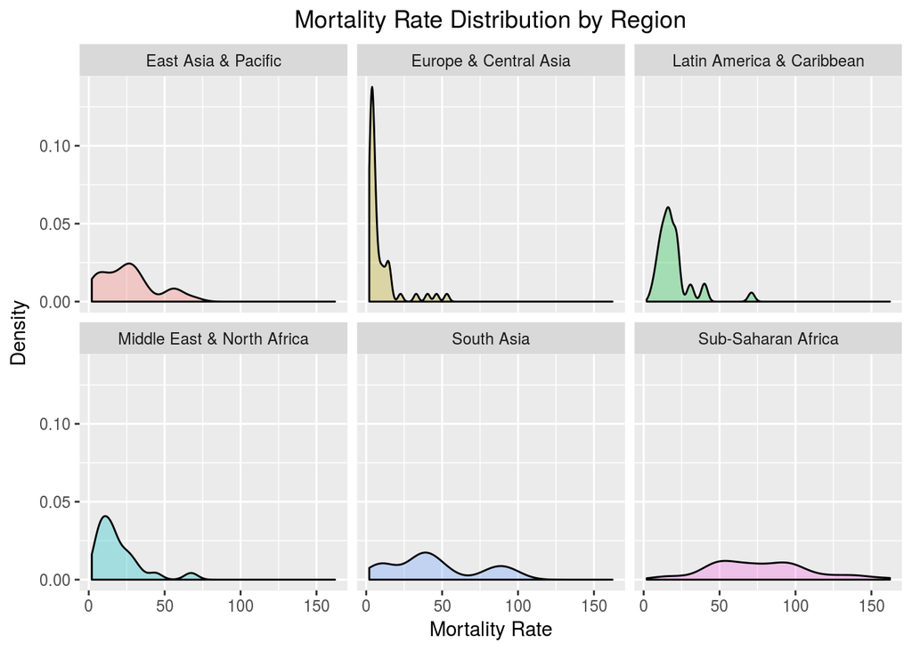

```r
ggplot(pop2014[pop2014$region != "North America",], mapping = aes(MOR, fill = region)) +
  geom_density(adjust = 0.75, alpha = 0.3) +
  facet_wrap(~region) +
  labs(x = "Mortality Rate", y = "Density") +
  ggtitle("Mortality Rate Distribution by Region") +
  theme(plot.title = element_text(hjust = 0.5), legend.position = "none")
```

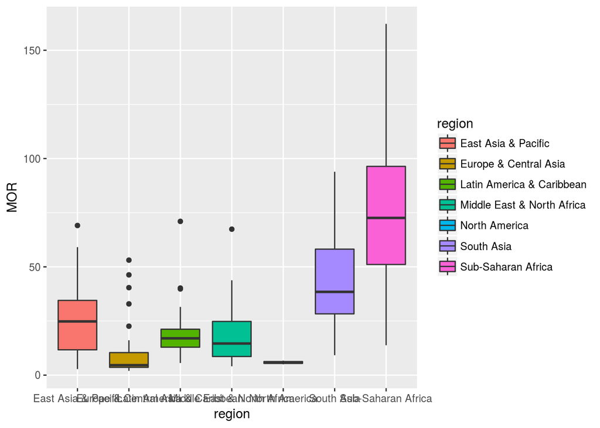

```r
ggplot(data=pop2014, aes(x=region, y=MOR, fill=region)) +
  geom_boxplot()
```

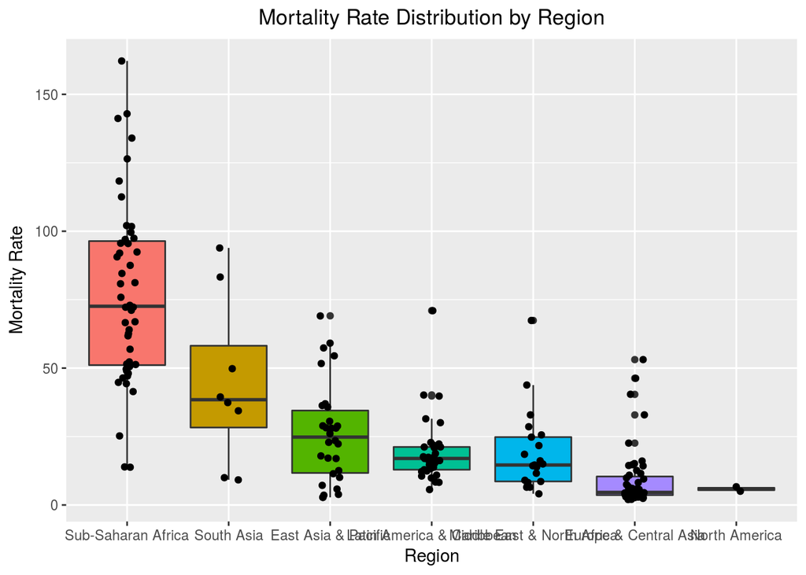

```r
pop2014$region <- factor(pop2014$region,
                         levels = c("Sub-Saharan Africa",
                                    "South Asia",
                                    "East Asia & Pacific",
                                    "Latin America & Caribbean",
                                    "Middle East & North Africa",
                                    "Europe & Central Asia",
                                    "North America"
                                    ))

ggplot(data=pop2014, aes(x=region, y=MOR, fill=region)) +
  geom_boxplot() +
  geom_jitter(width = 0.1) +
  labs(x = "Region", y = "Mortality Rate") +
  ggtitle("Mortality Rate Distribution by Region") +
  theme(plot.title = element_text(hjust = 0.5), legend.position = "none")
```

However, what can we do about the x-axis labels? We can add a new line for each point.

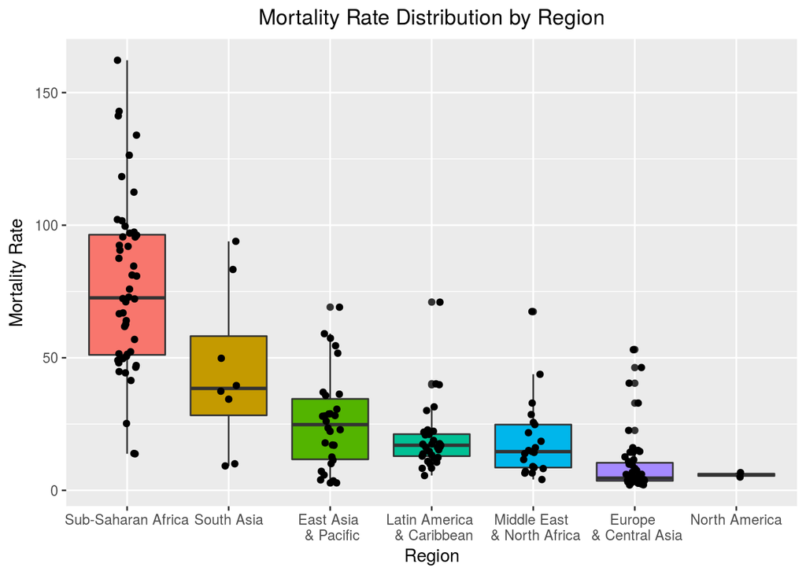

```r
levels(pop2014$region) <- gsub("&", "\n &", levels(pop2014$region))

ggplot(data=pop2014, aes(x=region, y=MOR, fill=region)) +
  geom_boxplot() +
  geom_jitter(width = 0.1) +
  labs(x = "Region", y = "Mortality Rate") +
  ggtitle("Mortality Rate Distribution by Region") +
  theme(plot.title = element_text(hjust = 0.5), legend.position = "none")
```

So we started very simply and immediately were able to add multiple layers to add a variety of complexity.

### Scatter Plots

Another popular geom is to use [`geom_point()`](http://ggplot2.tidyverse.org/reference/geom_point.html) to produce scatter plots.

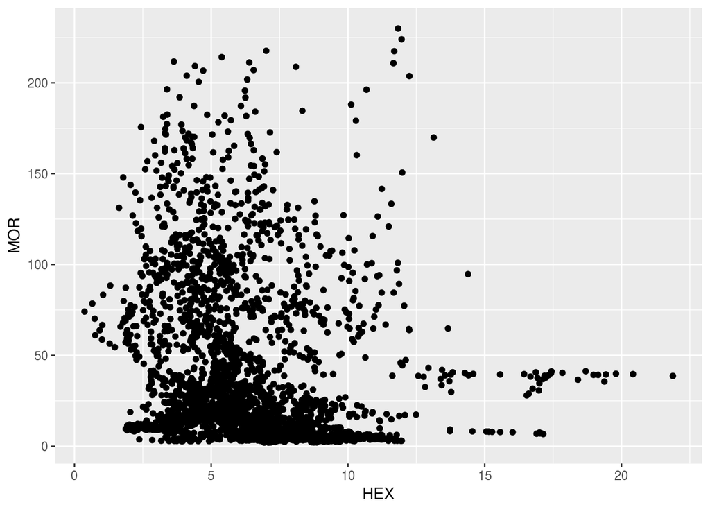

```r
ggplot(d, aes(x = HEX, y = MOR)) +
  geom_point()
```

But one problem we can immediately see is that this includes multiple years.

One way to overcome this is facet (sometimes called trellis) using [`facet_wrap()`](http://ggplot2.tidyverse.org/reference/facet_wrap.html)

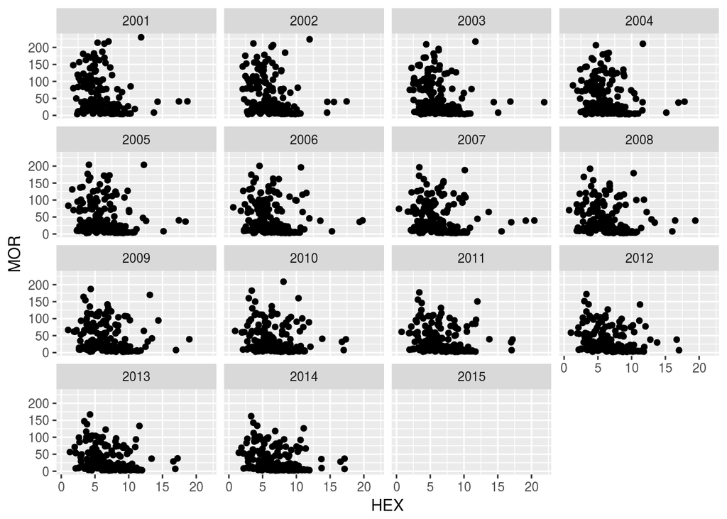

```r
ggplot(d, aes(x = HEX, y = MOR)) +
  geom_point() +
  facet_wrap(~year)
```

Oh - so we have many years. Maybe we want to simplify our plot to only consider four years: 2001, 2005, 2009, and 2013.

What would we use?

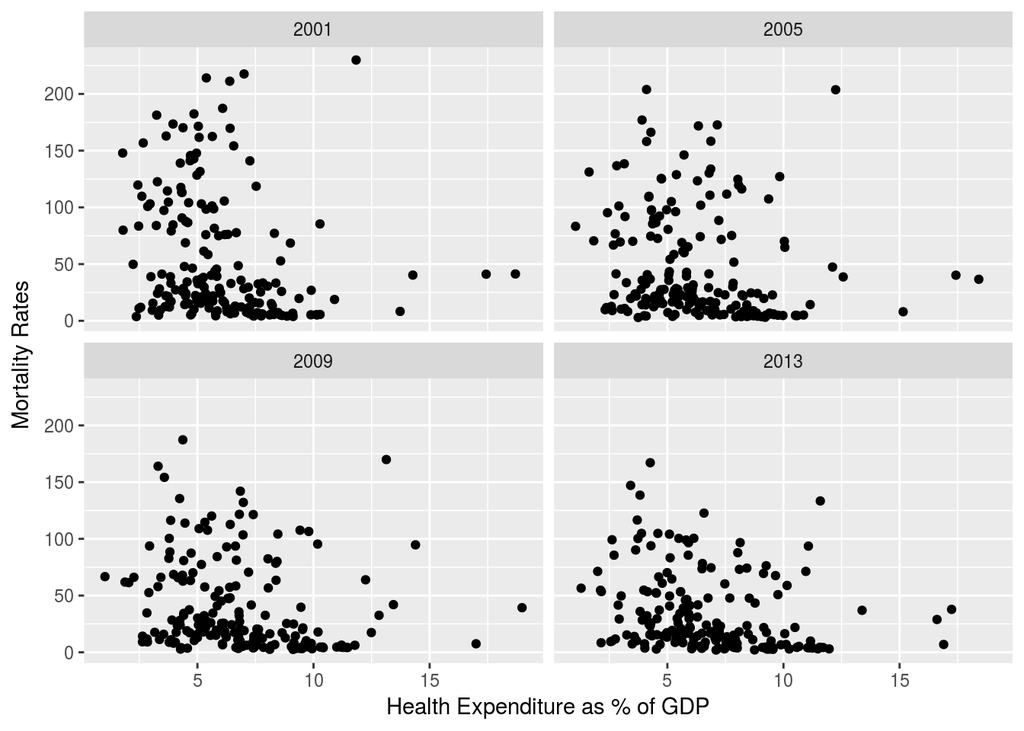

```r
years <- c(2001, 2005, 2009, 2013)

d1 <- d[d$year %in% years,]

ggplot(d1, aes(x = HEX, y = MOR)) +
  geom_point() +
  facet_wrap(~year) +
  labs(x = "Health Expenditure as % of GDP", y = "Mortality Rates")
```

Let’s also modify each axis to log scale…

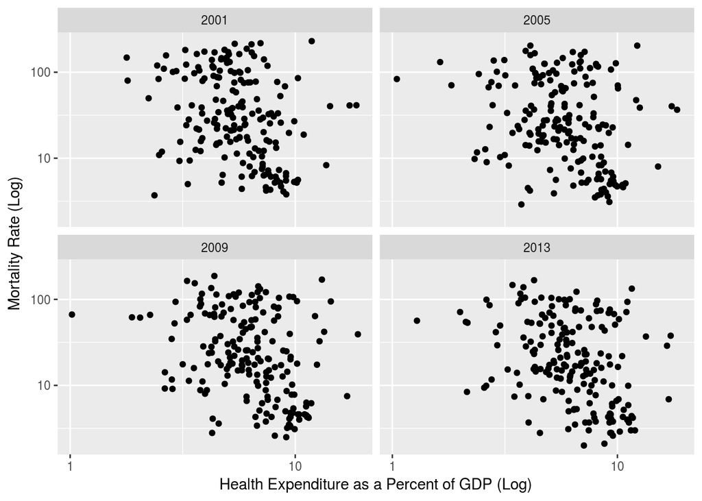

```r
ggplot(d1, aes(x = HEX, y = MOR)) +
  geom_point() +
  facet_wrap(~year) +
  scale_x_log10() +
  scale_y_log10() +
  labs(x = "Health Expenditure as a Percent of GDP (Log)", y = "Mortality Rate (Log)")
```

Now, we can add regressions (with confidence interval) by adding the `geom_smooth(method=lm)` level…

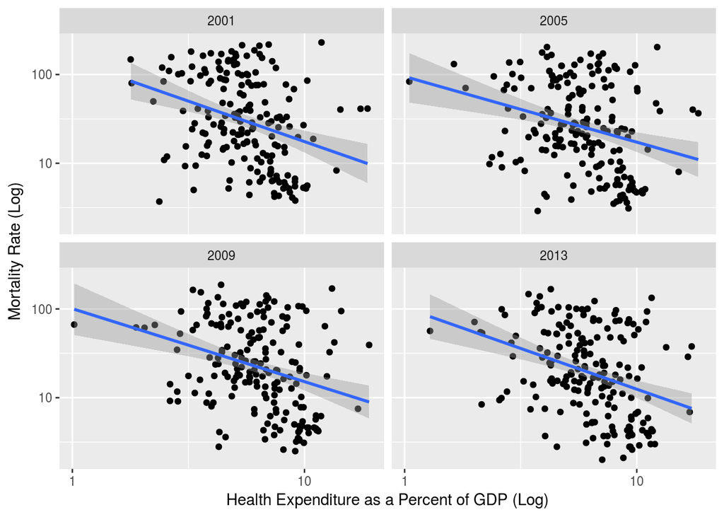

```r
ggplot(d1, aes(x = HEX, y = MOR)) +
  geom_point() +
  facet_wrap(~year) +
  scale_x_log10() +
  scale_y_log10() +
  labs(x = "Health Expenditure as a Percent of GDP (Log)", y = "Mortality Rate (Log)") +
  geom_smooth(method=lm)
```

So there appears to be a negative relationship between Mortality Rate and Health Expenditures. This could make sense: the more money a country spends on health care, yields better health outcomes like a lower mortality rate.

However, how does this relationship hold by region?

To test the effect of region on this relationship, let’s add `region` as a `color` parameter.

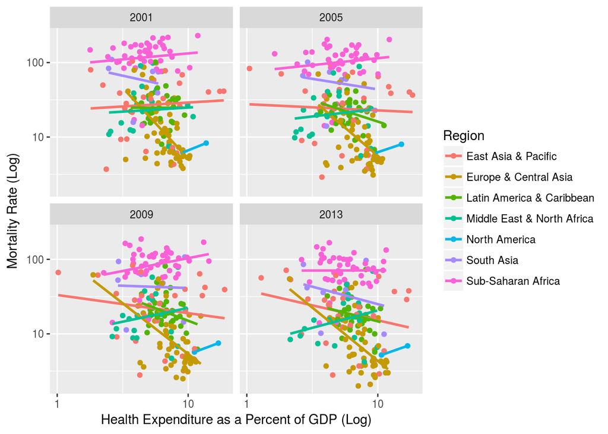

```r
ggplot(d1, aes(x = HEX, y = MOR, color = region)) +
  geom_point() +
  facet_wrap(~year) +
  scale_x_log10() +
  scale_y_log10() +
  labs(x = "Health Expenditure as a Percent of GDP (Log)", y = "Mortality Rate (Log)") +
  scale_color_discrete(guide = guide_legend(title = "Region")) +
  geom_smooth(method=lm, se=FALSE)  # Don't add shaded confidence region
```

Interesting. This negative relationship does not hold on a regional basis. This will be critical to remember when we consider more formal regression modeling tomorrow.

### Line Plots (Time Series)

Another important plot we can use is a line plot to show time series data.

For this plot, we’ll use the [`geom_line()`](http://ggplot2.tidyverse.org/reference/geom_path.html) function.

But recall, our dataset is on the country-level, yet we’re looking for a measure on a region-level.

Yet we can use our trusty friend `dplyr` (also included in `tidyverse`) to create a data manipulation.

```r
d$r.MOR <- d$MOR * (d$POP) / 1000

d2 <- d %>%
  na.omit() %>% # note the na.omit is very important!
  group_by(region, year) %>%
  summarise(t.MOR=sum(r.MOR),
            t.POP=sum(POP)) %>%
  mutate(MOR.rate = t.MOR / (t.POP / 1000))
```

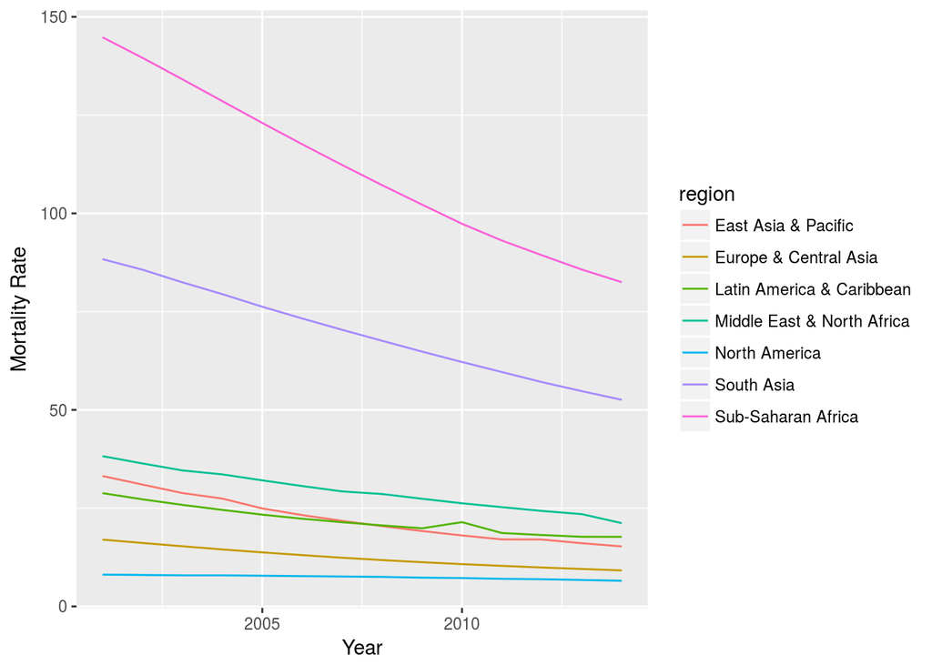

```r
ggplot(d2, aes(year, MOR.rate, color = region)) +
  geom_line() +
  labs(x = "Year", y = "Mortality Rate")
```

We can also adding points by including `geom_point()`.

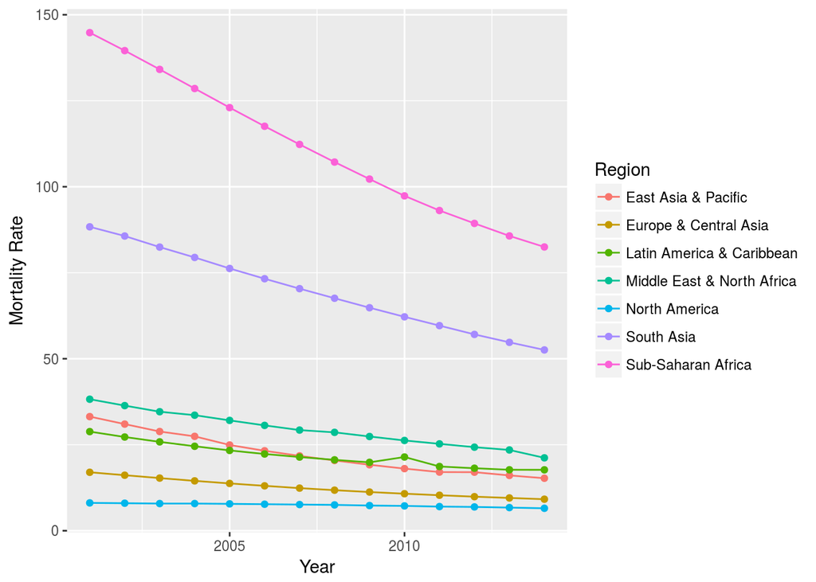

```r
ggplot(d2, aes(year, MOR.rate, color = region)) +
  geom_line() +
  geom_point() +
  labs(x = "Year", y = "Mortality Rate") +
  scale_color_discrete(guide = guide_legend(title = "Region"))
```

However, the legends/labels are difficult to connect which line is which.

Therefore, let’s move the legend to the bottom.

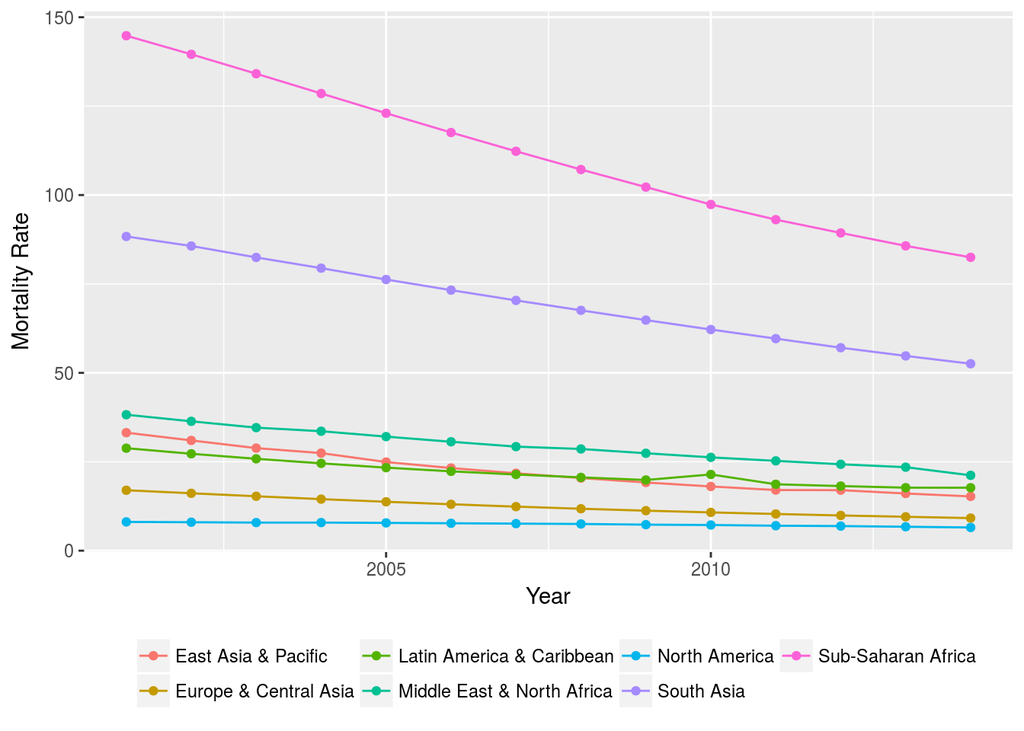

```r
g <- ggplot(d2, aes(year, MOR.rate, color = region)) +
  geom_line() +
  geom_point() +
  labs(x = "Year", y = "Mortality Rate") +
  theme(legend.position="bottom") +
  guides(col = guide_legend(ncol = 4, title = " "))

g   #new ggplot2 object g
```

[output not shown]